# Risk Prediction for Police Stolen Vehicle Operations Data

WNAR 2026

Jessica Minnier, PhD · Jeffrey Tyner, PhD · Officer Michael Terrett · Sergeant Bradley Nutting

Oregon Health & Science University · Portland Police Bureau

June 16, 2026

## Background

- Portland vehicle thefts more than **doubled**: 5,076 reports (2016) → **10,891** (2022) — first per capita among comparable U.S. cities (487 per 100,000).
- Increasingly tied to violent crime: stolen cars used as transport for shootings, robberies, homicides.
- After a 2021 directive de-prioritized some traffic enforcement, self-initiated stops fell **~44%**.
- PPB’s response — **Stolen Vehicle Operations (SVO)**: targeted missions under one goal, *fewer stops, better outcomes*.
- The statistical question: from cues observable **before** a stop, estimate P(vehicle stolen) — to guide the field decision and withstand later review.

## From biomarker screening to traffic stops

At the **Knight Cancer Institute** we screen large panels of candidate biomarkers and keep the few that carry signal — the same OHSU group built **Beat AML**, among the largest primary-leukemia datasets of its kind. SVO data has the same shape: many observable cues, mostly uninformative.

- Officers record cues; the task is to find the informative subset and combine it.
- Both fields, independently, named these cues **enrichment factors**.
- Factors were first elicited from **interviews with top-performing officers** who reliably spot stolen vehicles.
- OHSU joined in **2022** for independent, skeptical review; a **DOJ/BJA** grant funded the work.

**Team**

- **PPB** — Officer M. Terrett (15-yr software / data-science career before policing) built the forms, database, and models; Sgt. B. Nutting founded and runs the missions
- **OHSU Knight Cancer** — J. Tyner, J. Minnier, K. Watanabe-Smith, N. Long (Beat AML analytics)
- **Funding** — U.S. Department of Justice (BJA)
- **Scope** — PPB → **five agencies**

## The data-collection instrument

Before a stop, an officer records observable cues, each coded as a binary indicator.

**Vehicle characteristics**  
static, observable before the stop

- Plates: missing, switched, expired, returns stolen
- Condition: windows, spray paint, donut tire, panels
- Status: flagged sold, rental, uninsured, on stolen list

**Encounter behavior**  
observed during the stop

- Eluding (7 sub-types)
- Driver obscuring identity

**Outcomes**  
confirmed after the stop

**Vehicle stolen**

**Active warrant**

**Firearm recovered**

Up to **39 binary enrichment factors** per stop. The vehicle/behavior distinction becomes important for both modeling and admissibility.

## Data overview

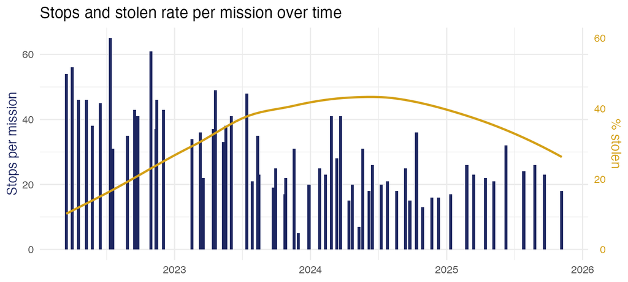

Navy bars: stops per mission (left axis). Gold line: % stolen, loess-smoothed (right axis).

**1,930**  
stops (48 test removed)

**5**  
agencies, 2022–2025

**39**  
binary factors

**28 / 17 / 4%**  
stolen / warrant / firearm  
all 1,930 stops

## A selected and evolving sample

Not a random sample of vehicles on the road:

- Officers are trained to spot enrichment factors, then stop the vehicles those factors flag — the data **conditions on suspicion**.
- The stopped-population rate is not the driving-population rate.
- Officers are **retrained between missions** — the selection rule, and the instrument itself, keep shifting.
- Collection form: **14 versions**; 8 factors appear only in later versions, coded absent for earlier stops.
- Driver race and sex **missing for ~27%** of stops.
- **Quasi-complete separation** for several factors.

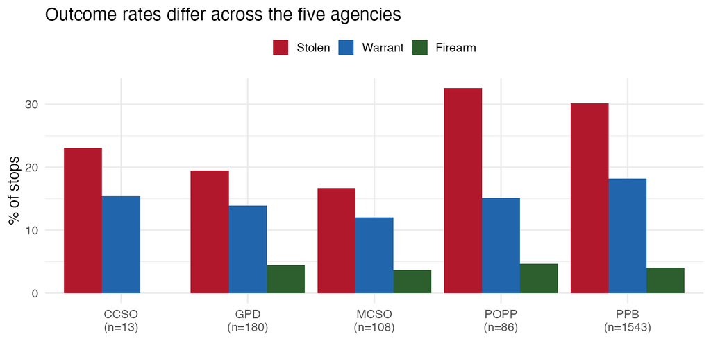

Outcome rates differ across the five agencies, which also apply the instrument somewhat differently.

## Statistical framework

Features of the problem that shape the methods:

- *p* is moderate relative to the number of events (e.g., 67 firearm recoveries).
- Predictors are correlated (seven elude sub-types; overlapping plate indicators).
- Several factors exhibit **separation**, so maximum-likelihood estimates diverge.
- Sampling depends on the covariates, which constrains what the estimates represent.

## Univariate screening under separation

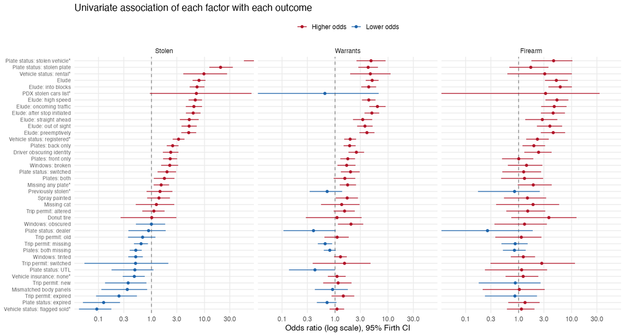

- Logistic regression fit with **Firth’s penalized likelihood** (Firth, 1993; Heinze & Schemper, 2002).
- Plate and elude factors are the strongest signals; the three outcomes share only part of it.

## The number of factors is a weak summary

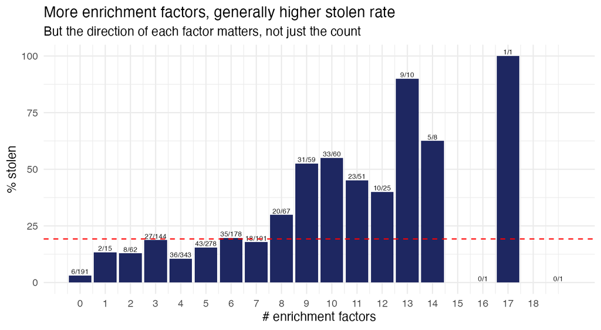

- Stolen rate rises with the count of factors — but the count alone is not informative.
- Some factors are **protective**, so two vehicles with the same count can differ sharply in risk.
- Motivates a model on the **individual factors**, not their sum.

## Selected factors for stolen vehicle

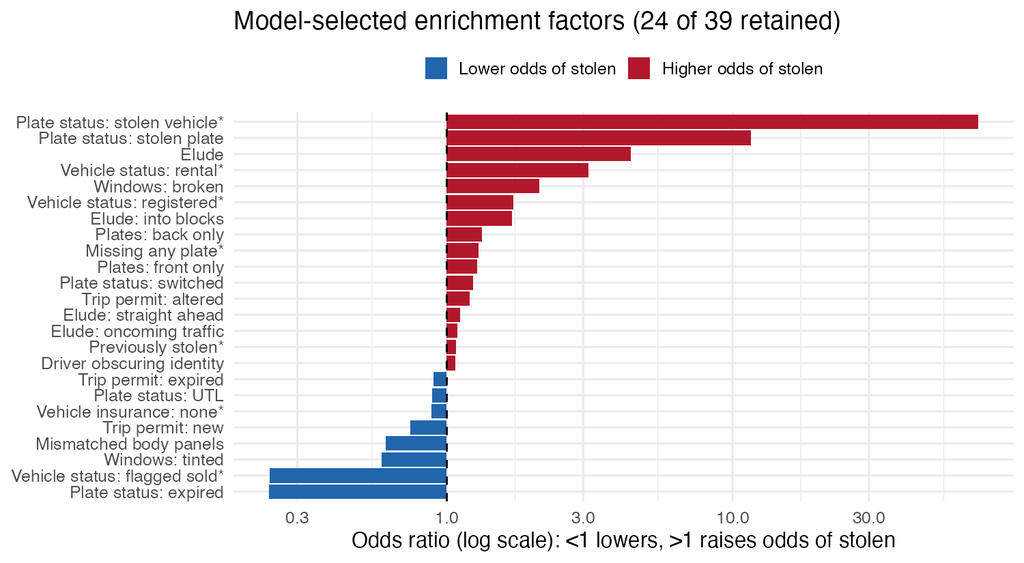

## Shared and outcome-specific factors

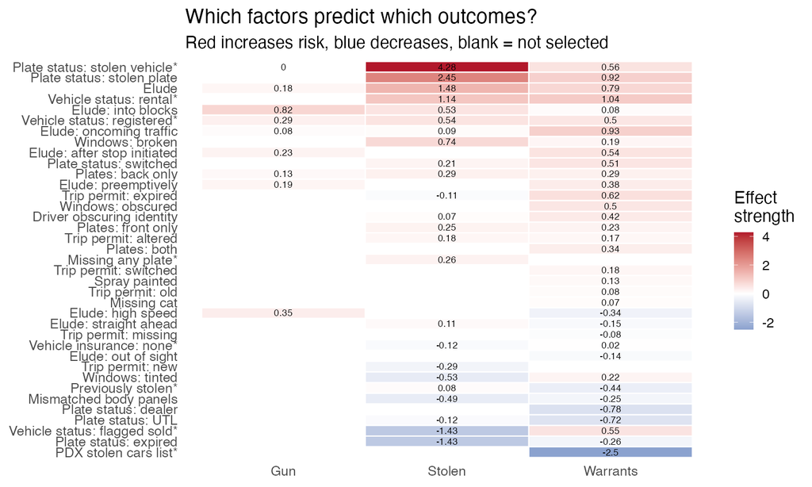

## Selected factors, by outcome

Selected factors (LASSO, λ<sub>min</sub>). **†** **behavior-related** factor: eluding sub-types and driver-obscuring

**Shared by all three outcomes** Plate returns stolen · back-plate-only · registered-vehicle status · elude† · elude into blocks† · elude into oncoming traffic†

**Stolen-specific** Missing any plate · new trip-permit tag

**Warrant-specific** Spray-painted · obscured windows · dealer / switched / old / missing trip-permit tags · PDX stolen-cars list · elude out of sight†

**Firearm** No firearm-only factor survives selection. Everything it keeps is shared with the stolen or warrant model; its only added signal is behavioral — high-speed elude†, preemptive elude†, elude after stop initiated† (shared with warrants).

- A vehicle-status core (stolen plate, registration, plate configuration) is important for all three outcomes.
- Behavior† factors cluster in the warrant and firearm models; stolen associated more with vehicle features.

## Pre-stop information versus encounter behavior

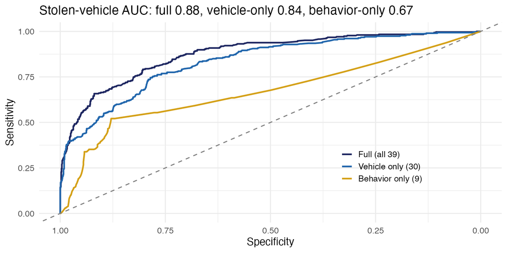

Out-of-fold AUC for stolen vehicle:

- Full model (39 factors): **0.88**
- **Vehicle characteristics only (30): 0.84**
- Behavior only (9): 0.67
- Behavioral signal is mostly eluding — observed only after the stop begins, so partly **post-treatment**, and more subjective.
- Vehicle-only gives up little discrimination and stays usable **before** the stop.

## Temporal stability

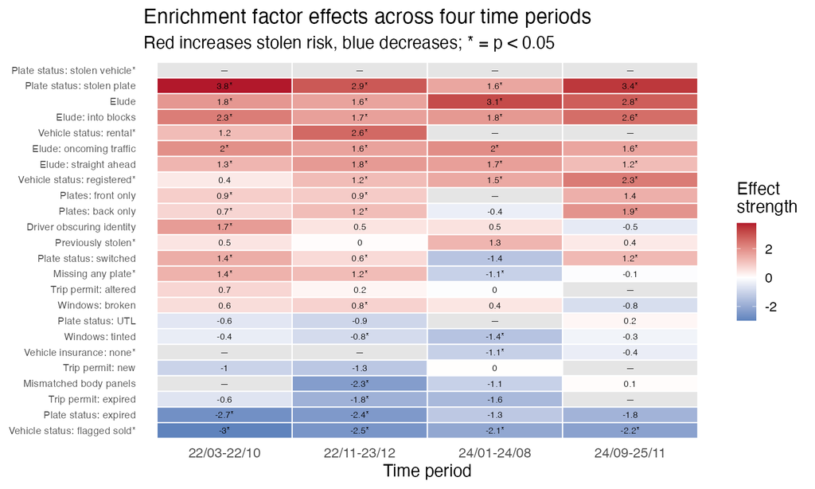

Factor effects estimated within four periods, with a 2024 state pursuit-policy change as one boundary.

- A dash indicates separation within a period, with no comparison group.
- Asterisks denote *p* < 0.05 for the factor’s within-period univariable association.
- Directions are largely stable; magnitudes drift, partly because officers are retrained between missions.

## Discrimination

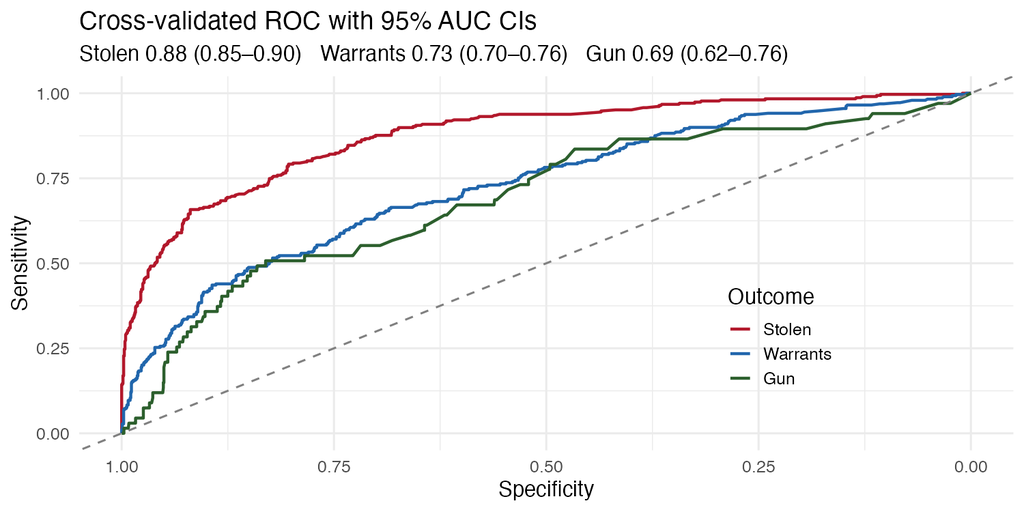

Areas under the curve from 10-fold cross-validated, out-of-fold predictions (95% DeLong CIs):

| Outcome | AUC | 95% CI |
| --- | --- | --- |
| Vehicle stolen | **0.88** | 0.85–0.90 |
| Active warrant | 0.73 | 0.70–0.76 |
| Firearm recovered | 0.69 | 0.62–0.76 |

Discrimination is strong for stolen vehicles. Firearm recovery is most difficult (not the main goal of study) with ~4% prevalence and 67 events. Each vehicle is scored by fits that excluded its fold, so factor selection and the penalty are not tuned on the vehicle being predicted.

## Separation of predicted probabilities

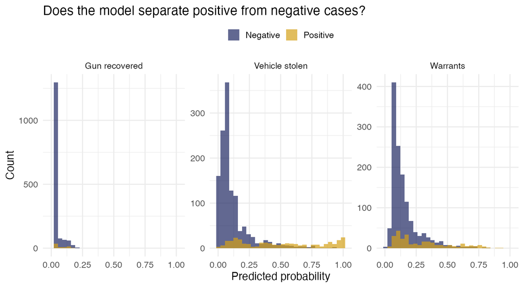

Out-of-fold predictions by true outcome: stolen vehicles separate more than warrants and firearms, consistent with lower AUCs.

## Calibration

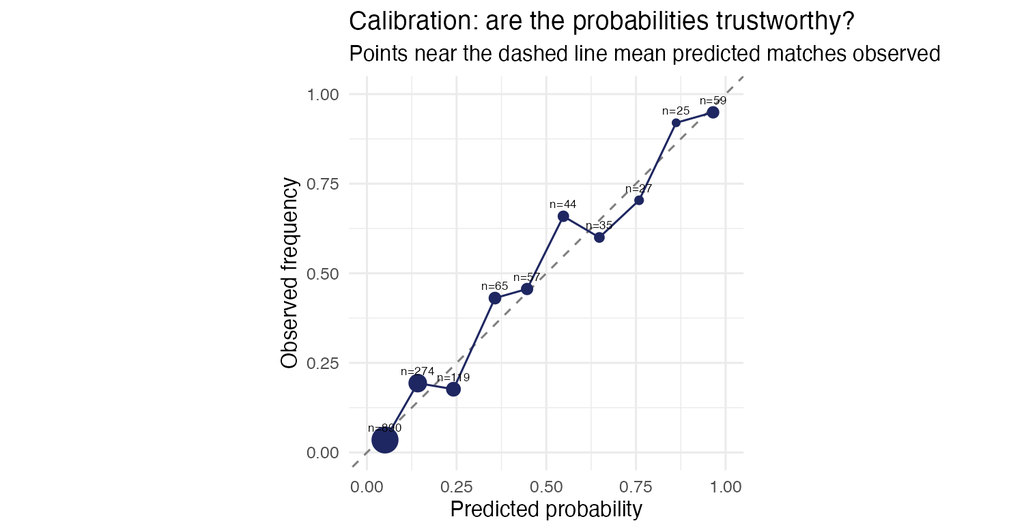

- Out-of-fold predicted probabilities against observed frequencies, grouped into deciles of risk
- Agreement is close across the range, including the sparse high-probability deciles.
- Calibration is important in a practically applied risk or decision making model

## Decision thresholds: stolen vehicle

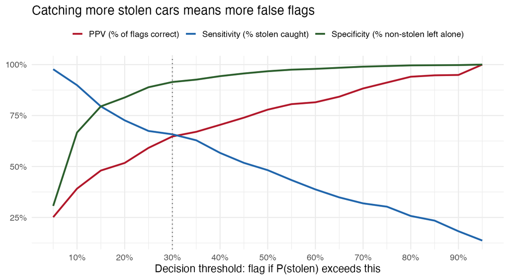

Out-of-fold, 307 events among 1,595 vehicles:

| P(stolen) ≥ | Sens | Spec | PPV | Flagged |
| --- | --- | --- | --- | --- |
| 0.10 | 0.90 | 0.67 | 0.39 | 705 |
| 0.25 | 0.67 | 0.89 | 0.59 | 350 |
| 0.50 | 0.48 | 0.97 | 0.78 | 190 |
| 0.75 | 0.30 | 0.99 | 0.91 | 102 |

The choice of threshold is an operational decision. An agency prioritizing recovery accepts lower specificity; one prioritizing restraint accepts lower sensitivity.

## Decision thresholds: active warrant

| P(warrant) ≥ | Sens | Spec | PPV | Flagged |
| --- | --- | --- | --- | --- |
| 0.10 | 0.82 | 0.42 | 0.24 | 994 |
| 0.25 | 0.49 | 0.85 | 0.42 | 336 |
| 0.50 | 0.21 | 0.97 | 0.64 | 94 |
| 0.75 | 0.05 | 1.00 | 0.82 | 17 |

For warrants, discrimination is weaker (AUC 0.73), so a given sensitivity comes at a higher cost in false flags. Each agency would set outcome-specific thresholds rather than a single rule.

## A field scoring instrument

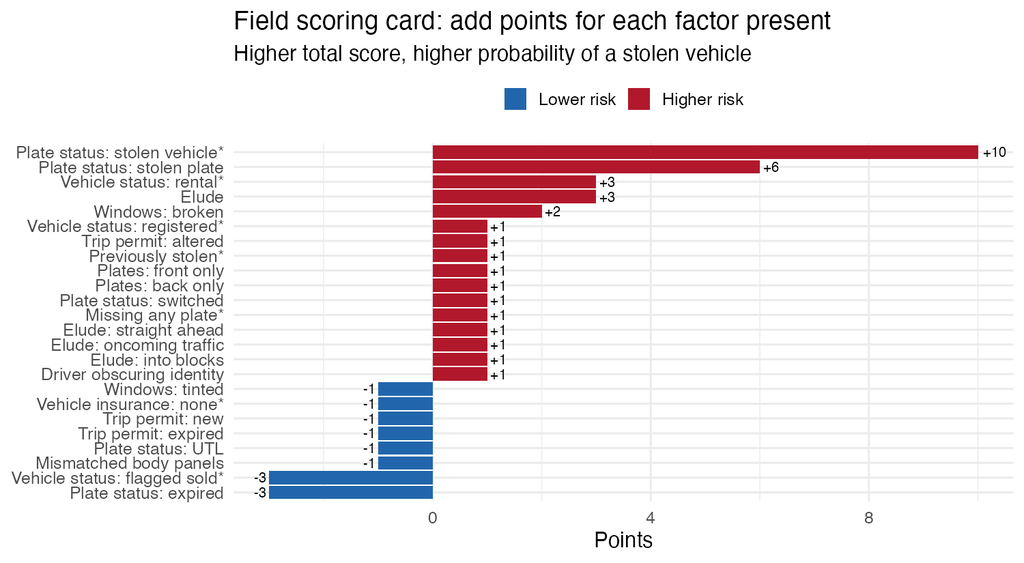

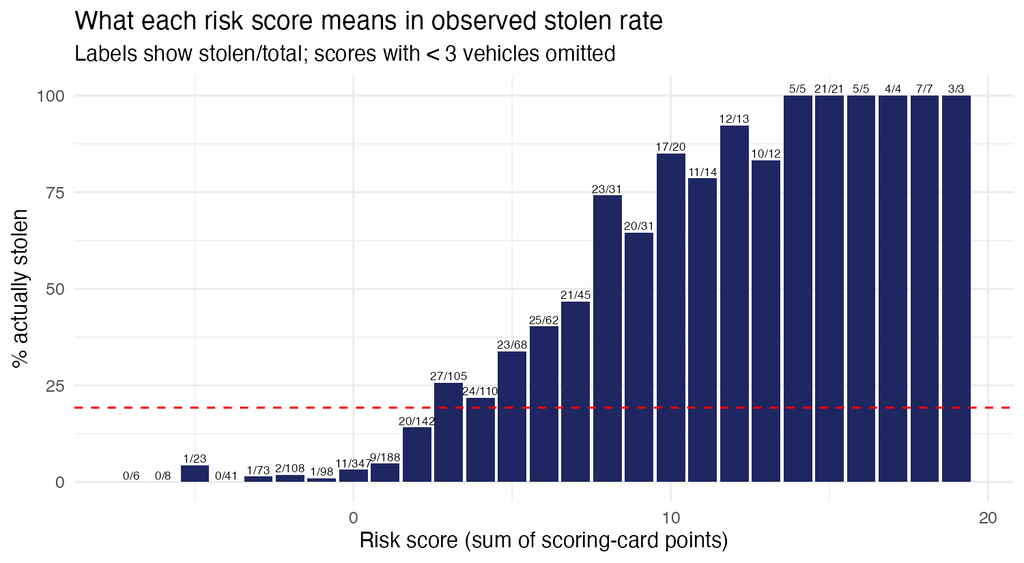

## Algorithmic fairness

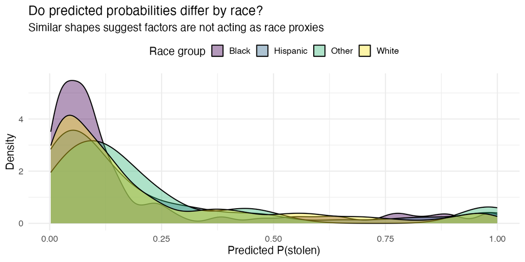

## What the estimates mean under outcome-dependent sampling

Officers stop vehicles on the covariates, and the stopping rule shifts as training changes.

- The fitted probabilities are conditional on being stopped. They estimate risk within the stopped population, not for vehicles officers would have let pass (Lum & Isaac, 2016).
- Selection is performative: a deployed score changes which vehicles get stopped, and that changes the data the next fit sees (Perdomo et al., 2020). The ranking within the stopped population still holds; the absolute risks need periodic recalibration.

## Evidence considerations

A stop requires a justification that the officer can articulate and a court can later review.

**Supportive**

- A documented, calibrated probability is reviewable after the fact.
- Vehicle characteristics are observable before the stop and independently verifiable.
- The vehicle-only model reaches AUC 0.84, so a defensible rule need not rely on behavior.

**Cautions**

- Eluding is subjective and largely post-initiation, a weak basis for the initial decision.
- Selection and the 14-version instrument bound the claims the score can support.
- Any deployed model must be versioned and frozen, since retraining changes its outputs.

## Limitations

- The cohort is selected on the predictors and shaped by training, so external validity is limited.
- The instrument changed across 14 versions, and several factors are recorded inconsistently across agencies.
- Driver demographics are missing for roughly a quarter of stops, which constrains the fairness analysis.
- Firearm recovery is too rare for reliable modeling at present.
- Stops are modeled as independent; repeat vehicles, officers, and within-mission clustering are not adjusted for.
- The evaluation is internal cross-validation; no external or prospective validation has been done.

## Summary and future directions

- Penalized logistic regression handles 39 correlated, separation-prone factors and discriminates stolen vehicles well (cross-validated AUC 0.88) with good calibration.
- Vehicle characteristics alone reach AUC 0.84, supporting a pre-stop rule that does not depend on subjective behavior.
- We deliver an operating-characteristic curve and a scoring instrument rather than a fixed cutoff, leaving the threshold to each agency.
- Next steps: prospective validation, monitoring for calibration drift under deployment, and extending the fairness analysis using patrol-area demographics.

## References

- Tibshirani, R. (1996). Regression shrinkage and selection via the lasso. *JRSS-B*, 58(1). [[DOI]](https://doi.org/10.1111/j.2517-6161.1996.tb02080.x)
- Zou, H. & Hastie, T. (2005). Regularization and variable selection via the elastic net. *JRSS-B*, 67(2). [[DOI]](https://doi.org/10.1111/j.1467-9868.2005.00503.x)
- Friedman, J., Hastie, T. & Tibshirani, R. (2010). Regularization paths for generalized linear models via coordinate descent. *J. Stat. Softw.*, 33(1). [[DOI]](https://doi.org/10.18637/jss.v033.i01)
- Firth, D. (1993). Bias reduction of maximum likelihood estimates. *Biometrika*, 80(1). [[DOI]](https://doi.org/10.1093/biomet/80.1.27)
- Heinze, G. & Schemper, M. (2002). A solution to the problem of separation in logistic regression. *Stat. Med.*, 21(16). [[DOI]](https://doi.org/10.1002/sim.1047)
- Van Calster, B. et al. (2019). Calibration: the Achilles heel of predictive analytics. *BMC Medicine*, 17:230. [[DOI]](https://doi.org/10.1186/s12916-019-1466-7)
- Hardt, M., Price, E. & Srebro, N. (2016). Equality of opportunity in supervised learning. *NeurIPS*. [[arXiv]](https://arxiv.org/abs/1610.02413)
- Perdomo, J. et al. (2020). Performative prediction. *ICML*. [[PMLR]](https://proceedings.mlr.press/v119/perdomo20a.html)
- Lum, K. & Isaac, W. (2016). To predict and serve? *Significance*, 13(5). [[DOI]](https://doi.org/10.1111/j.1740-9713.2016.00960.x)

### Thank you

Jessica Minnier · Jeffrey Tyner · Officer Michael Terrett · Sergeant Bradley Nutting

OHSU Knight Cancer Institute · Portland Police Bureau

Supported by the U.S. Department of Justice. With thanks to PPB, GPD, MCSO, POPP, and CCSO.